# customer_segmentation

### Gap Statistics

Gap statitistics build off of the elbow method, but add an extra layer: we compare intracluster variation of different values of k to their expected values under the null reference distribution of data.

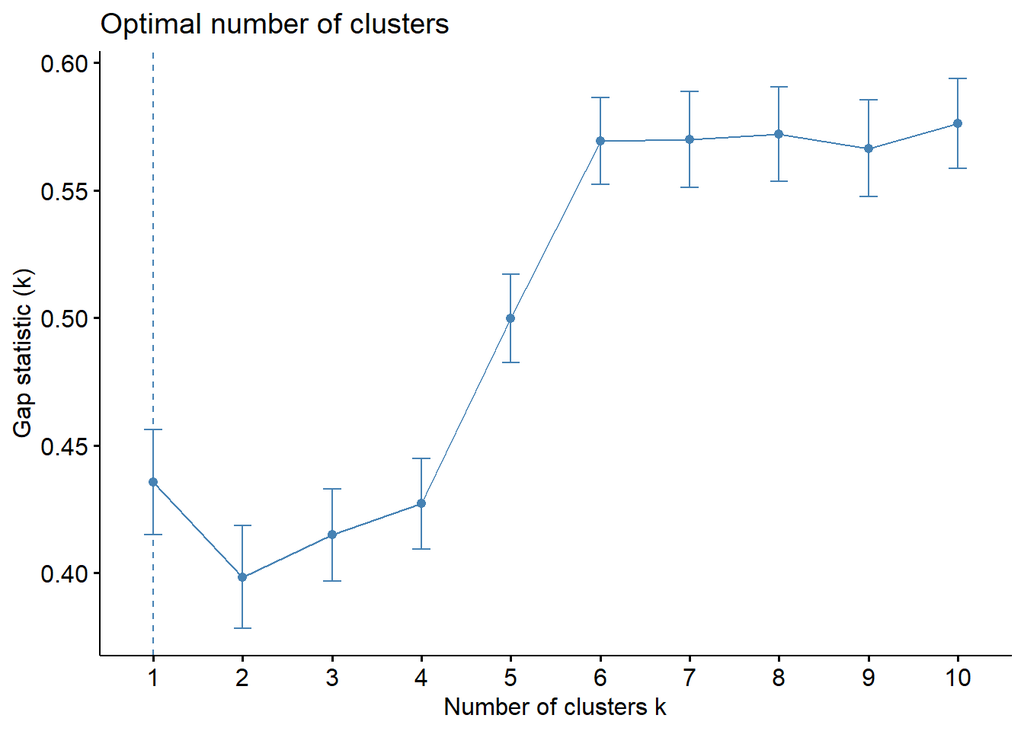

This method suggest 1 as the optimal number of gaps, but that’s not useful for analysis. This method can certainly be useful, but for this particular set of data, we will ignore this approach when determining the optimal k value.

Of the remaining two methods, the elbow method suggests 4 or 5 as optimal, and the average silhouette approach suggests 6. Let’s use the average of these- 5- for our k-value.

## Step 2

### K-means model

Next, we simply run our k-means model using 5 for k. This gives us the hard-to-decipher result:

```
## K-means clustering with 5 clusters of sizes 79, 23, 23, 39, 36
##
## Cluster means:
##        age annual_income_k spending_score_1_100
## 1 43.08861        55.29114             49.56962
## 2 45.21739        26.30435             20.91304
## 3 25.52174        26.30435             78.56522
## 4 32.69231        86.53846             82.12821
## 5 40.66667        87.75000             17.58333
##
## Clustering vector:
##   [1] 2 3 2 3 2 3 2 3 2 3 2 3 2 3 2 3 2 3 2 3 2 3 2 3 2 3 2 3 2 3 2 3 2 3 2 3 2
##  [38] 3 2 3 2 3 2 3 2 3 1 1 1 1 1 1 1 1 1 1 1 1 1 1 1 1 1 1 1 1 1 1 1 1 1 1 1 1
##  [75] 1 1 1 1 1 1 1 1 1 1 1 1 1 1 1 1 1 1 1 1 1 1 1 1 1 1 1 1 1 1 1 1 1 1 1 1 1
## [112] 1 1 1 1 1 1 1 1 1 1 1 1 4 5 4 1 4 5 4 5 4 5 4 5 4 5 4 5 4 5 4 1 4 5 4 5 4
## [149] 5 4 5 4 5 4 5 4 5 4 5 4 5 4 5 4 5 4 5 4 5 4 5 4 5 4 5 4 5 4 5 4 5 4 5 4 5
## [186] 4 5 4 5 4 5 4 5 4 5 4 5 4 5 4
##
## Within cluster sum of squares by cluster:
## [1] 30138.051  8948.609  4622.261 13972.359 17669.500
##  (between_SS / total_SS =  75.6 %)
##
## Available components:
##
## [1] "cluster"      "centers"      "totss"        "withinss"     "tot.withinss"
## [6] "betweenss"    "size"         "iter"         "ifault"
```

Let’s visualize it on a graph with a principal component analysis (PCA), which simplifies complexity in this data (which has 3 dimensions) into 2 dimensions.

### PCA

First, we need to look at the importance of all three components:

```
## Importance of components:
##                            PC1     PC2     PC3
## Standard deviation     26.4625 26.1597 12.9317
## Proportion of Variance  0.4512  0.4410  0.1078
## Cumulative Proportion   0.4512  0.8922  1.0000
```

Components one (income) and two (spending) seem most important, so we’ll use those in our visualization:

### Visualization

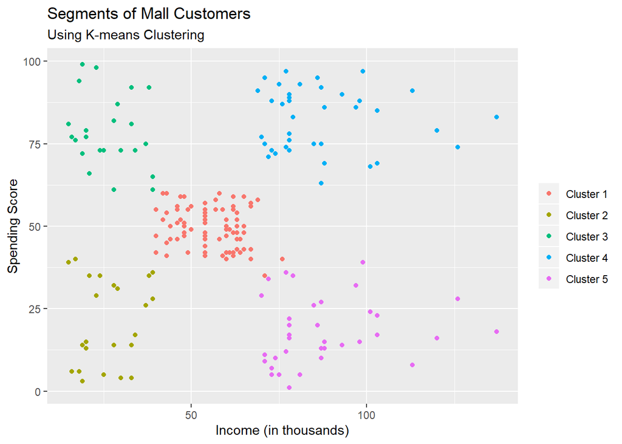

This visualization misses out on the third dimension- age- but we can see that we’ve successfully segmented customers into 5 categories using k-means clustering!